# 📌주제 분석

: 은행의 대출 상환 실패 리스크를 줄이기 위한 아이디어를 세워라!

- 대출 받은 고객의 특징을 분석해 위험 요인을 분석: 대출 상환 실패에 가장 큰 요인은 무엇인가? -> EDA를 통해 중요한 Feature들을 판별
- 구체적인 대출 상품 타겟층을 포지셔닝
- 은행의 리스크 부담을 줄이는 전략 도출

# 읽기

```python
# 필요한 라이브러리 불러오기
import numpy as np
import pandas as pd

# 데이터 시각화를 위한 라이브러리
import matplotlib.pyplot as plt
import seaborn as sns
import os
os.getcwd() # 현재 위치 확인
```

```
'C:\\Users\\ppy04\\OneDrive\\바탕 화면\\workspace\\INSIGHT\\insight-10th\\code\\13155a1\\인사이콘'
```

```python
# 라이브러리 로드
import pandas as pd
# csv 파일 -> pd.read_csv
# 데이터 프레임으로 저장

loan = pd.read_csv('./Loan_default.csv')
print(type(loan))
loan.head(10) #상위 10개의 데이터 보여줌
```

```
<class 'pandas.core.frame.DataFrame'>
```

|  | LoanID | Age | Income | LoanAmount | CreditScore | MonthsEmployed | NumCreditLines | InterestRate | LoanTerm | DTIRatio | Education | EmploymentType | MaritalStatus | HasMortgage | HasDependents | LoanPurpose | HasCoSigner | Default |
| --- | --- | --- | --- | --- | --- | --- | --- | --- | --- | --- | --- | --- | --- | --- | --- | --- | --- | --- |
| 0 | I38PQUQS96 | 56 | 85994 | 50587 | 520 | 80 | 4 | 15.23 | 36 | 0.44 | Bachelor's | Full-time | Divorced | Yes | Yes | Other | Yes | 0 |
| 1 | HPSK72WA7R | 69 | 50432 | 124440 | 458 | 15 | 1 | 4.81 | 60 | 0.68 | Master's | Full-time | Married | No | No | Other | Yes | 0 |
| 2 | C1OZ6DPJ8Y | 46 | 84208 | 129188 | 451 | 26 | 3 | 21.17 | 24 | 0.31 | Master's | Unemployed | Divorced | Yes | Yes | Auto | No | 1 |
| 3 | V2KKSFM3UN | 32 | 31713 | 44799 | 743 | 0 | 3 | 7.07 | 24 | 0.23 | High School | Full-time | Married | No | No | Business | No | 0 |
| 4 | EY08JDHTZP | 60 | 20437 | 9139 | 633 | 8 | 4 | 6.51 | 48 | 0.73 | Bachelor's | Unemployed | Divorced | No | Yes | Auto | No | 0 |
| 5 | A9S62RQ7US | 25 | 90298 | 90448 | 720 | 18 | 2 | 22.72 | 24 | 0.10 | High School | Unemployed | Single | Yes | No | Business | Yes | 1 |
| 6 | H8GXPAOS71 | 38 | 111188 | 177025 | 429 | 80 | 1 | 19.11 | 12 | 0.16 | Bachelor's | Unemployed | Single | Yes | No | Home | Yes | 0 |
| 7 | 0HGZQKJ36W | 56 | 126802 | 155511 | 531 | 67 | 4 | 8.15 | 60 | 0.43 | PhD | Full-time | Married | No | No | Home | Yes | 0 |
| 8 | 1R0N3LGNRJ | 36 | 42053 | 92357 | 827 | 83 | 1 | 23.94 | 48 | 0.20 | Bachelor's | Self-employed | Divorced | Yes | No | Education | No | 1 |
| 9 | CM9L1GTT2P | 40 | 132784 | 228510 | 480 | 114 | 4 | 9.09 | 48 | 0.33 | High School | Self-employed | Married | Yes | No | Other | Yes | 0 |

- `'LoanID'` : 각 대출에 대한 고유 식별자
- `'Age'` : 대출자의 나이
- `'Income'`: 대출자의 연봉
- `'LoanAmount'` : 빌린 돈의 액수
- `'CreditScore'` : 대출자의 신용도를 나타내는 신용 점수
- `'MonthsEmployed'` : 대출자가 고용된 달 수
- `'NumCreditLines'` : 대출자가 개설한 신용 라인 수
- `'InterestRate'` : 대출 이자율
- `'LoanTerm'` : 대출 기간(월)
- `'DTIRatio'` : 소득대비 부채를 나타내는 총부채상환비율
- `'Education'` : 대출자가 달성한 최고 수준의 교육
- `'EmploymentType'` : 대출자의 고용형태
- `'MaritalStatus'` : 대출자의 혼인상태
- `'HasMortgage'` : 대출자가 담보대출을 받았는지 여부 (Y/N)
- `'HasDependents'` : 대출자가 부양가족이 있는지 여부 (Y/N)
- `'LoanPurpose'` : 대출의 목적
- `'HasCoSigner'` : 대출에 공동서명자가 있는지 여부 (Y/N)
- `'Default'` : 대출 부도(=대출 상환 실패) 여부를 나타내는 이진 목표 변수 (0/1)
- 범주형
  - 명목형: `'EmploymentType'`, `'MaritalStatus'`, `'HasMortgage'`, `'HasDependents'`, `'LoanPurpose'`, `'HasCoSigner'`
  - 순서형:
- 수치형
  - 이산형: `'Age'`, `'Income'`, `'LoanAmount'`, `'Income'`, `'CreditScore'`, `'MonthsEmployed'`, `'NumCreditLines'`, `'LoanTerm'`, `'Education'`(수치형으로 바꿈)
  - 연속형:`'InterestRate'`, `'DTIRatio'`,

# 전처리

## 데이터 셋 확인

- 변수 확인
- RAW data 확인

```python
loan.info() # 데이터의 결측치, 타입, 컬럼 특징
```

```
<class 'pandas.core.frame.DataFrame'>
RangeIndex: 255347 entries, 0 to 255346
Data columns (total 18 columns):
 #   Column          Non-Null Count   Dtype
---  ------          --------------   -----
 0   LoanID          255347 non-null  object
 1   Age             255347 non-null  int64
 2   Income          255347 non-null  int64
 3   LoanAmount      255347 non-null  int64
 4   CreditScore     255347 non-null  int64
 5   MonthsEmployed  255347 non-null  int64
 6   NumCreditLines  255347 non-null  int64
 7   InterestRate    255347 non-null  float64
 8   LoanTerm        255347 non-null  int64
 9   DTIRatio        255347 non-null  float64
 10  Education       255347 non-null  object
 11  EmploymentType  255347 non-null  object
 12  MaritalStatus   255347 non-null  object
 13  HasMortgage     255347 non-null  object
 14  HasDependents   255347 non-null  object
 15  LoanPurpose     255347 non-null  object
 16  HasCoSigner     255347 non-null  object
 17  Default         255347 non-null  int64
dtypes: float64(2), int64(8), object(8)
memory usage: 35.1+ MB
```

- 255347명의 사람에 대한 데이터

```python
loan.isnull().sum()
```

```
LoanID            0
Age               0
Income            0
LoanAmount        0
CreditScore       0
MonthsEmployed    0
NumCreditLines    0
InterestRate      0
LoanTerm          0
DTIRatio          0
Education         0
EmploymentType    0
MaritalStatus     0
HasMortgage       0
HasDependents     0
LoanPurpose       0
HasCoSigner       0
Default           0
dtype: int64
```

- 결측값이 없는 듯?

## 결측값 처리

```python
loan.describe()
```

|  | Age | Income | LoanAmount | CreditScore | MonthsEmployed | NumCreditLines | InterestRate | LoanTerm | DTIRatio | Default |
| --- | --- | --- | --- | --- | --- | --- | --- | --- | --- | --- |
| count | 255347.000000 | 255347.000000 | 255347.000000 | 255347.000000 | 255347.000000 | 255347.000000 | 255347.000000 | 255347.000000 | 255347.000000 | 255347.000000 |
| mean | 43.498306 | 82499.304597 | 127578.865512 | 574.264346 | 59.541976 | 2.501036 | 13.492773 | 36.025894 | 0.500212 | 0.116128 |
| std | 14.990258 | 38963.013729 | 70840.706142 | 158.903867 | 34.643376 | 1.117018 | 6.636443 | 16.969330 | 0.230917 | 0.320379 |
| min | 18.000000 | 15000.000000 | 5000.000000 | 300.000000 | 0.000000 | 1.000000 | 2.000000 | 12.000000 | 0.100000 | 0.000000 |
| 25% | 31.000000 | 48825.500000 | 66156.000000 | 437.000000 | 30.000000 | 2.000000 | 7.770000 | 24.000000 | 0.300000 | 0.000000 |
| 50% | 43.000000 | 82466.000000 | 127556.000000 | 574.000000 | 60.000000 | 2.000000 | 13.460000 | 36.000000 | 0.500000 | 0.000000 |
| 75% | 56.000000 | 116219.000000 | 188985.000000 | 712.000000 | 90.000000 | 3.000000 | 19.250000 | 48.000000 | 0.700000 | 0.000000 |
| max | 69.000000 | 149999.000000 | 249999.000000 | 849.000000 | 119.000000 | 4.000000 | 25.000000 | 60.000000 | 0.900000 | 1.000000 |

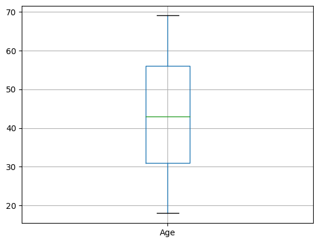

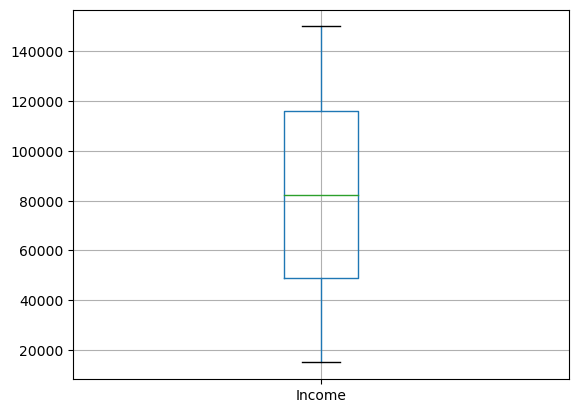

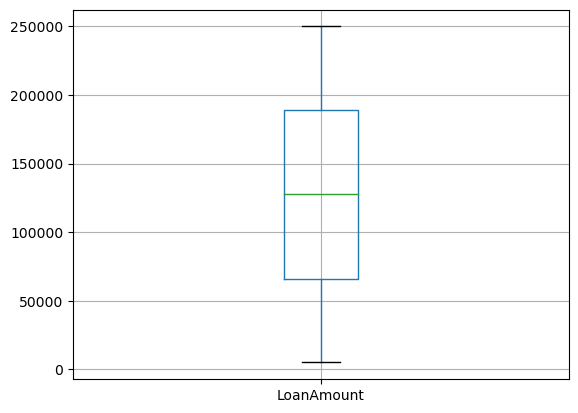

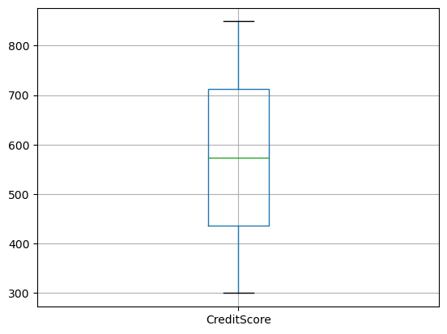

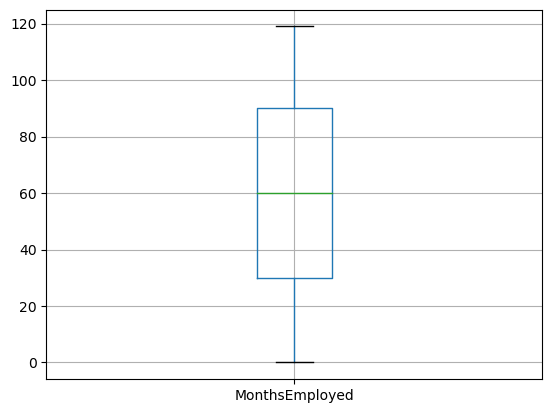

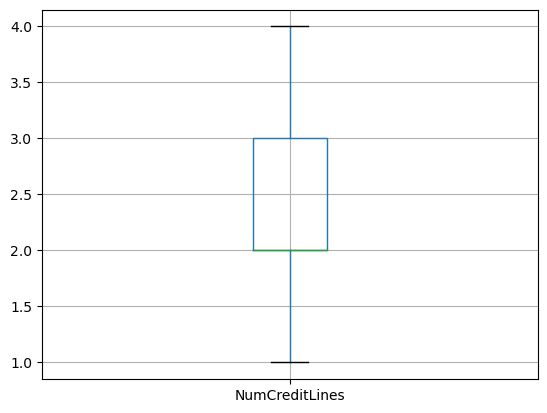

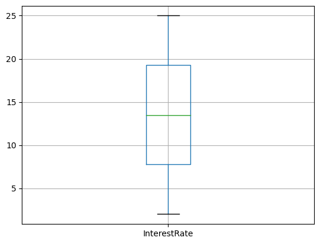

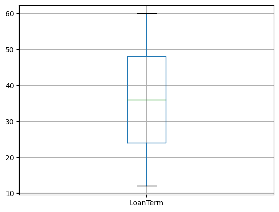

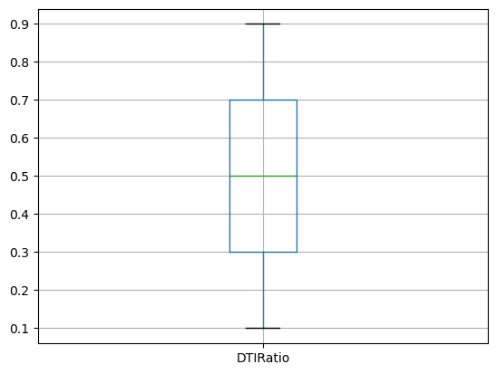

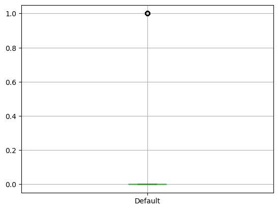

```python
import matplotlib.pylab as plt

for i in loan.describe().columns:
    loan[[i]].boxplot()
    plt.show()
```

- 딱히 이상치가 나타나지 않음

## Feature Engineering

### Education을 수치로 변환

```python
loan["Education"].value_counts()
```

```
Bachelor's     64366
High School    63903
Master's       63541
PhD            63537
Name: Education, dtype: int64
```

-> Bachelor's, High School, Master's, PhD(=박사): 총 네 개의 Education 범주가 존재

- High School: 1
- Bachelor's: 2
- Master's: 3
- PhD: 4

```python
# 학력 수준을 숫자로 매핑할 딕셔너리를 만듭니다.
education_mapping = {
    "High School": 1,
    "Bachelor's": 2,
    "Master's": 3,
    "PhD": 4
}

# 'Education' 열을 숫자로 바꿉니다.
loan['Education'] = loan['Education'].replace(education_mapping)

loan.head()
```

|  | LoanID | Age | Income | LoanAmount | CreditScore | MonthsEmployed | NumCreditLines | InterestRate | LoanTerm | DTIRatio | Education | EmploymentType | MaritalStatus | HasMortgage | HasDependents | LoanPurpose | HasCoSigner | Default |
| --- | --- | --- | --- | --- | --- | --- | --- | --- | --- | --- | --- | --- | --- | --- | --- | --- | --- | --- |
| 0 | I38PQUQS96 | 56 | 85994 | 50587 | 520 | 80 | 4 | 15.23 | 36 | 0.44 | 2 | Full-time | Divorced | Yes | Yes | Other | Yes | 0 |
| 1 | HPSK72WA7R | 69 | 50432 | 124440 | 458 | 15 | 1 | 4.81 | 60 | 0.68 | 3 | Full-time | Married | No | No | Other | Yes | 0 |
| 2 | C1OZ6DPJ8Y | 46 | 84208 | 129188 | 451 | 26 | 3 | 21.17 | 24 | 0.31 | 3 | Unemployed | Divorced | Yes | Yes | Auto | No | 1 |
| 3 | V2KKSFM3UN | 32 | 31713 | 44799 | 743 | 0 | 3 | 7.07 | 24 | 0.23 | 1 | Full-time | Married | No | No | Business | No | 0 |
| 4 | EY08JDHTZP | 60 | 20437 | 9139 | 633 | 8 | 4 | 6.51 | 48 | 0.73 | 2 | Unemployed | Divorced | No | Yes | Auto | No | 0 |

### Yes를 1, No를 0으로 변환

```python
YN_mapping = {
    "Yes":1,
    "No": 0
}
loan = loan.replace(YN_mapping)

loan.head()
```

|  | LoanID | Age | Income | LoanAmount | CreditScore | MonthsEmployed | NumCreditLines | InterestRate | LoanTerm | DTIRatio | Education | EmploymentType | MaritalStatus | HasMortgage | HasDependents | LoanPurpose | HasCoSigner | Default |
| --- | --- | --- | --- | --- | --- | --- | --- | --- | --- | --- | --- | --- | --- | --- | --- | --- | --- | --- |
| 0 | I38PQUQS96 | 56 | 85994 | 50587 | 520 | 80 | 4 | 15.23 | 36 | 0.44 | 2 | Full-time | Divorced | 1 | 1 | Other | 1 | 0 |
| 1 | HPSK72WA7R | 69 | 50432 | 124440 | 458 | 15 | 1 | 4.81 | 60 | 0.68 | 3 | Full-time | Married | 0 | 0 | Other | 1 | 0 |
| 2 | C1OZ6DPJ8Y | 46 | 84208 | 129188 | 451 | 26 | 3 | 21.17 | 24 | 0.31 | 3 | Unemployed | Divorced | 1 | 1 | Auto | 0 | 1 |
| 3 | V2KKSFM3UN | 32 | 31713 | 44799 | 743 | 0 | 3 | 7.07 | 24 | 0.23 | 1 | Full-time | Married | 0 | 0 | Business | 0 | 0 |
| 4 | EY08JDHTZP | 60 | 20437 | 9139 | 633 | 8 | 4 | 6.51 | 48 | 0.73 | 2 | Unemployed | Divorced | 0 | 1 | Auto | 0 | 0 |

```python
loan.info()
```

```
<class 'pandas.core.frame.DataFrame'>
RangeIndex: 255347 entries, 0 to 255346
Data columns (total 18 columns):
 #   Column          Non-Null Count   Dtype
---  ------          --------------   -----
 0   LoanID          255347 non-null  object
 1   Age             255347 non-null  int64
 2   Income          255347 non-null  int64
 3   LoanAmount      255347 non-null  int64
 4   CreditScore     255347 non-null  int64
 5   MonthsEmployed  255347 non-null  int64
 6   NumCreditLines  255347 non-null  int64
 7   InterestRate    255347 non-null  float64
 8   LoanTerm        255347 non-null  int64
 9   DTIRatio        255347 non-null  float64
 10  Education       255347 non-null  int64
 11  EmploymentType  255347 non-null  object
 12  MaritalStatus   255347 non-null  object
 13  HasMortgage     255347 non-null  int64
 14  HasDependents   255347 non-null  int64
 15  LoanPurpose     255347 non-null  object
 16  HasCoSigner     255347 non-null  int64
 17  Default         255347 non-null  int64
dtypes: float64(2), int64(12), object(4)
memory usage: 35.1+ MB
```

## EDA/시각화

### 'Default'와의 관계 냅다 찍어보기

- 범주형 -> bar plot
- 수치형 -> histplot

으로 'Default'와의 관계를 찍어보았음

- 범주형: `'EmploymentType'`, `'MaritalStatus'`, `'HasMortgage'`, `'HasDependents'`, `'LoanPurpose'`, `'HasCoSigner'`
- 수치형:`'Age'`, `'Income'`, `'LoanAmount'`, `'CreditScore'`, `'MonthsEmployed'`, `'NumCreditLines'`, `'LoanTerm'`, `'Education'`,`'InterestRate'`, `'DTIRatio'`

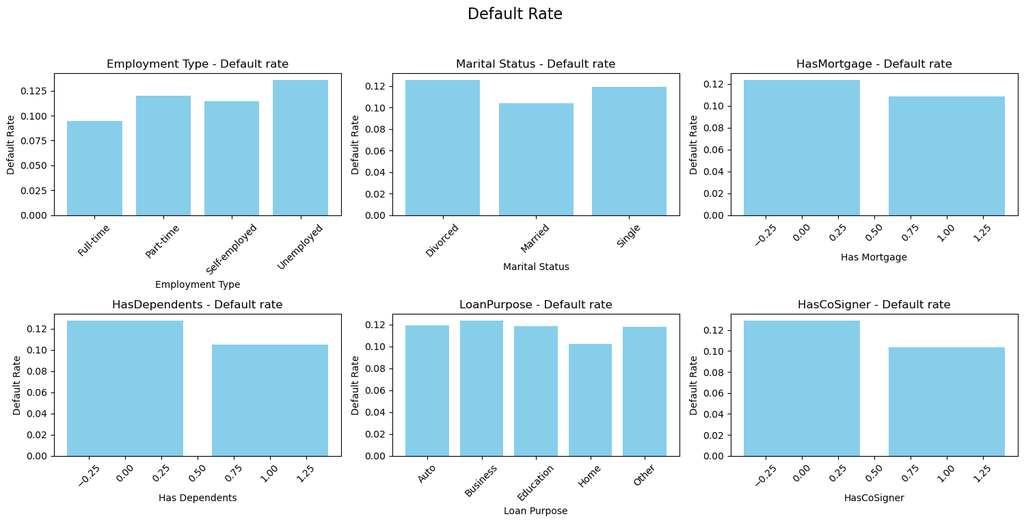

```python
loan = pd.DataFrame(loan)

# 'EmploymentType'에 따른 'Default'의 비율을 계산
result = loan.groupby('EmploymentType')['Default'].mean().reset_index()

# 2x3 서브플롯 생성
fig, axs = plt.subplots(2, 3, figsize=(15, 8))
fig.suptitle('Default Rate', fontsize=16)

# 첫 번째 서브플롯에 그래프 그리기 - Employment Type
axs[0, 0].bar(result['EmploymentType'], result['Default'], color='skyblue')
axs[0, 0].set_xlabel('Employment Type')
axs[0, 0].set_ylabel('Default Rate')
axs[0, 0].set_title('Employment Type - Default rate')
axs[0, 0].tick_params(axis='x', rotation=45)

# 나머지 서브플롯에 필요한 그래프 그리기
# axs[0, 1].bar(...) - MaritalStatus
result = loan.groupby('MaritalStatus')['Default'].mean().reset_index()

axs[0, 1].bar(result['MaritalStatus'], result['Default'], color='skyblue')
axs[0, 1].set_xlabel('Marital Status')
axs[0, 1].set_ylabel('Default Rate')
axs[0, 1].set_title('Marital Status - Default rate')
axs[0, 1].tick_params(axis='x', rotation=45)

# axs[0, 2].bar(...)
result = loan.groupby('HasMortgage')['Default'].mean().reset_index()

axs[0, 2].bar(result['HasMortgage'], result['Default'], color='skyblue')
axs[0, 2].set_xlabel('Has Mortgage')
axs[0, 2].set_ylabel('Default Rate')
axs[0, 2].set_title('HasMortgage - Default rate')
axs[0, 2].tick_params(axis='x', rotation=45)

# axs[1, 0].bar(...) - HasDependents
result = loan.groupby('HasDependents')['Default'].mean().reset_index()

axs[1, 0].bar(result['HasDependents'], result['Default'], color='skyblue')
axs[1, 0].set_xlabel('Has Dependents')
axs[1, 0].set_ylabel('Default Rate')
axs[1, 0].set_title('HasDependents - Default rate')
axs[1, 0].tick_params(axis='x', rotation=45)

# axs[1, 1].bar(...)
result = loan.groupby('LoanPurpose')['Default'].mean().reset_index()

axs[1, 1].bar(result['LoanPurpose'], result['Default'], color='skyblue')
axs[1, 1].set_xlabel('Loan Purpose')
axs[1, 1].set_ylabel('Default Rate')
axs[1, 1].set_title('LoanPurpose - Default rate')
axs[1, 1].tick_params(axis='x', rotation=45)

# axs[1, 2].bar(...)
result = loan.groupby('HasCoSigner')['Default'].mean().reset_index()

axs[1, 2].bar(result['HasCoSigner'], result['Default'], color='skyblue')
axs[1, 2].set_xlabel('HasCoSigner')
axs[1, 2].set_ylabel('Default Rate')
axs[1, 2].set_title('HasCoSigner - Default rate')
axs[1, 2].tick_params(axis='x', rotation=45)

# 그래프 간격 조정
plt.tight_layout(rect=[0, 0.03, 1, 0.95])

# 그래프 표시
plt.show()
```

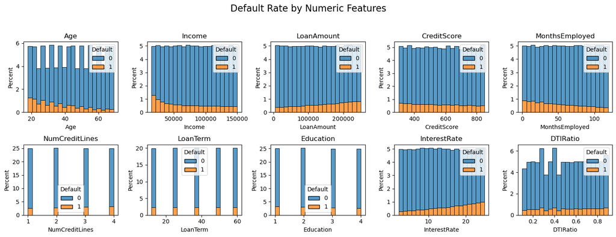

```python
loan = pd.DataFrame(loan)

# 서브플롯 그리드 생성
fig, axes = plt.subplots(2, 5, figsize=(15, 6))
fig.suptitle('Default Rate by Numeric Features', fontsize=16)

# 각 특성에 대한 Default의 비율을 histplot으로 그립니다.
numeric_features = ['Age', 'Income', 'LoanAmount', 'CreditScore', 'MonthsEmployed', 'NumCreditLines', 'LoanTerm', 'Education','InterestRate', 'DTIRatio']

for i, feature in enumerate(numeric_features):
    row, col = divmod(i, 5)
    sns.histplot(data=loan, x=feature, hue='Default', ax=axes[row, col], multiple='stack', bins=20, stat='percent')
    axes[row, col].set_title(feature)

# 그래프 간격 조정
plt.tight_layout(rect=[0, 0.03, 1, 0.95])

# 그래프 표시
plt.show()
```

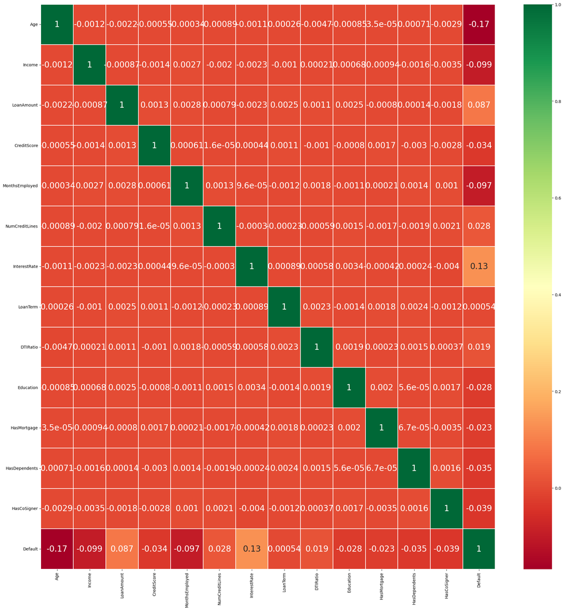

```python
sns.heatmap(loan.corr(),
            annot=True,
            cmap='RdYlGn',
            linewidths=0.2,
            annot_kws={'size': 20})
fig = plt.gcf()
fig.set_size_inches(25, 25)
plt.xticks(fontsize=10)
plt.yticks(fontsize=10)
plt.show()
```

### 가설 세워 보기

1. Employment type 중 unemployed에서 default rate가 가장 크게 나타남 -> income이 작을 수록 default rate가 높음. unemployed가 income이 0이어서 그런듯함. part-time이 그 다음으로 default rate가 높은 것도 income이 낮기 때문일 듯?
2. Employment type 중 full time보다 self-employment가 default rate가 높음. full time보다 self-employment가 income이 항상 낮다고 볼 수 없음. 아마 full-time은 일정하고 self-employment는 더 넓은 분포를 보일 듯. self-employment에서 소득이 낮은 비율이 높거나, 빌린 돈의 액수가 크기 때문일 듯. self-employment에서 대출의 목적이 business인 경우가 많고, 빌린 돈의 액수가 크면, 자영업을 하는 데 초기 비용이 많이 들기 때문에 default rate가 높은 것으로 볼 수 있음.
3. 담보 대출인 경우, 공동서명자가 있는 경우 대출 상환율이 높았음. 대출을 반환하지 않았을 때 가지는 risk가 크면 더 상환을 잘한다는 것을 알 수 있음.
4. 부양 가족이 없는 경우에 오히려 default rate가 높았음. 왜지?
5. 왜 신용점수와 default 값이 관련이없지?
6. 이자율이 높으면 default rate가 높음.
7. DIT Ratio와도 큰 관련성을 모르겠음.